# Class 9: Ryanair C: Low-Cost System

MG106 Strategic Management

José Ignacio González Rojas

j.i.gonzalez-rojas@lse.ac.uk

London School of Economics and Political Science

July 6, 2026

## Ryanair C shows how a coherent system changes the game

### Ryanair moved from vulnerable low fares to a reinforcing low-cost system

#### Last class

- Low fares alone were vulnerable
- Incumbent responses mattered
- Ryanair exposed itself through weak differentiation and expansion

#### Today

- What changed by 1999?
- Why was the system hard to imitate?
- How serious was Go’s challenge?

The question is not “why was Ryanair cheap?” but “why did the whole system work?”

## Three questions structure today’s system-fit analysis

### Choices, fit, imitation constraints, and response

#### Three questions for Ryanair C

1. How did Ryanair move from near failure to strong profitability?
2. What threats did Ryanair face in 1999?
3. How serious was the challenge posed by Go?

Explain why the choices work together, not just why each choice lowers cost.

# Ryanair’s new system changed costs and rival incentives together

## By 1999 Ryanair had become a focused low-cost carrier

### From me-too entrant to focused low-cost carrier

#### Customer

- Price-sensitive travellers
- Leisure and small-business passengers
- Willing to accept fewer frills

#### Operations

- Secondary airports
- Fast turnarounds
- Simple service
- Standardised fleet

#### Organisation

- Productivity-based pay
- Cost-conscious culture
- Direct selling and ancillary revenue
- Aggressive route discipline

Which change matters most because it reinforces the others?

## Ryanair’s activity system made low fares economically credible

### The choices reinforce each other

1. **Secondary airports** lower charges and congestion, enabling faster turnarounds and better punctuality.
2. **No-frills service** lowers service cost and clarifies the price-sensitive customer promise.
3. **Standardised aircraft** simplify maintenance and training, raising utilisation and reducing delays.
4. **Productivity incentives** lower unit labour cost and make employees share growth/cost discipline.
5. **Ancillary revenues** increase revenue per passenger and help sustain very low headline fares.

Name the link between each activity and another activity.

## Unit economics show the activity system turning into profit

### The 1999 revenue-and-cost exhibit makes the system concrete

#### Revenue per passenger

- Scheduled fares supplied most revenue
- Ancillary revenue added meaningful contribution
- Very low headline fares were supported by more than ticket revenue alone

#### Cost per passenger

- Staff, airport, distribution, aircraft, and fuel costs were tightly managed
- Operating expenses sat well below revenue
- The exhibit shows profit as the result of many reinforcing choices

Which activity would break first if Ryanair added complexity?

## Fit and trade-offs made imitation difficult for full-service airlines

### Full-service rivals had to copy trade-offs, not just prices

#### Ryanair’s fit

- Low fares require low costs
- Low costs require operational simplicity
- Simplicity requires customer trade-offs
- Trade-offs make the position clearer

#### Full-service tension

- Premium customers expect service
- Major airports are costly but valuable
- Unions and legacy systems constrain change
- Matching fares can undermine the core brand

Imitation is hard when rivals must copy the trade-offs, not just the visible price.

# Go tested whether incumbents could copy Ryanair without copying its trade-offs

## The imitation question depends on the imitator’s constraints

### Who was trying to copy Ryanair?

#### Green-field or focused entrants

- easyJet and other low-cost entrants could build from a cleaner base
- They still had to choose routes carefully
- Coexistence was easier when route overlap was limited

#### BA’s Go

- Backed by a full-service incumbent
- Tried to enter low-cost markets
- Carried some legacy constraints and strategic ambiguity
- Could either compete or disrupt the segment

When is imitation dangerous, and when is it self-defeating?

## Route overlap reveals whether Go built its own position or entered Ryanair’s game

### Exhibit-style comparison from the case

#### Ryanair

- 34 routes
- 2 routes overlap with low-cost rivals
- About 6% overlap
- One overlap was initiated by Ryanair

#### Go

- 17 routes
- 9 routes overlap with low-cost rivals
- About 53% overlap
- In most overlaps, Go entered second or third

Use route overlap as evidence of strategy, not just as a statistic.

## Go’s Straddling Problem

**Straddling means trying to serve two incompatible logics at once.**

Go had to look low-cost enough to compete with Ryanair, but it was still connected to British Airways’ full-service organisation, labour system, brand expectations, and route logic.

Can Go copy Ryanair’s economics without copying Ryanair’s trade-offs?

## A route-choice game shows why Ryanair’s likely response matters

### Keep the sequential logic qualitative

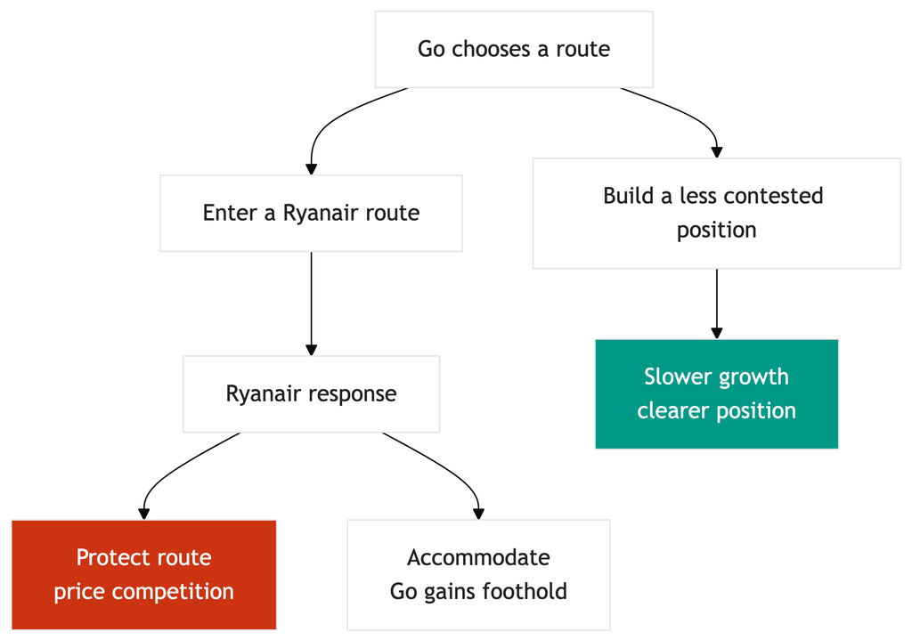

What is Go’s best outside option if Ryanair fights?

## Backward induction starts from Ryanair’s likely response

### Reason from the response back to Go’s entry decision

1. If Go enters a core Ryanair route, ask whether Ryanair has incentives to protect it.
2. If Ryanair protects the route, Go faces price competition inside Ryanair’s system.
3. Knowing that, Go should compare entry with its outside option.
4. Ryanair can also shape the game by expanding early and claiming attractive routes.

Backward induction means reasoning from the likely response back to the first move.

# Sustainability depends on preserving fit while growing

## Partial imitation fails when it copies pieces without fit

### Copying pieces is not copying fit

#### Visible pieces are copyable

- Low fares
- Simple service
- Advertising as low-cost
- Secondary-airport claims

#### The system is harder

- Cost culture
- Labour and productivity rules
- Airport bargaining
- Route discipline
- Customer expectations and trade-offs

An imitator can copy activities and still miss the system that makes them work together.

## Success created imitation, growth, and discipline risks

### Success creates new risks

#### Imitation

Low-cost entrants copy visible features; O’Leary must protect system fit and route discipline.

#### Go / BA

A deep-pocketed incumbent may disrupt routes; Ryanair must avoid fighting on bad terms.

#### Growth

Expansion can dilute cost discipline; Ryanair must protect operational simplicity.

#### Slack

Success can weaken urgency; Ryanair must protect the cost-conscious culture.

## O’Leary’s response should preserve difference, not just intensify rivalry

### Decision prompt

#### Possible responses

- Ignore weak imitators
- Defend core routes aggressively
- Expand first into attractive routes
- Reinforce cost discipline internally

#### Evaluation criteria

- Does this preserve system fit?
- Does it avoid destructive overlap?
- Does it deter the right rivals?
- Does it protect growth without adding complexity?

The recommendation should preserve difference, not simply intensify rivalry.

# Transfer: system-fit answers explain reinforcement and constraints

## Strong imitation answers identify what can and cannot be copied

### Assessment transfer

A strong answer:

1. identifies the focal firm’s activity system;
2. explains how choices reinforce each other;
3. identifies what the imitator copies;
4. identifies what the imitator cannot copy because of constraints or trade-offs;
5. uses evidence to show whether imitation changes the game or enters the rival’s game on bad terms.

## Ryanair C shows that strategy is a system of reinforcing choices

### Ryanair C in one sentence

Ryanair became harder to attack because it stopped being merely a low-fare entrant and became a coherent low-cost system.

Strategy is a system of choices that shapes both your costs and your rivals’ incentives.

## Project transfer: analyse the system before judging imitation

**For your group project**

When analysing a firm’s advantage, ask:

1. Which choices reinforce each other?
2. What trade-offs make the position credible?
3. Which rivals can copy pieces but not the full system?
4. How do competitor responses change the attractiveness of the strategy?